# Word Cloud

Kaushal Khatiwada

2024-04-23

```r
library(rvest)
library(tm)
```

```r
library(wordcloud)
urls<- "https://thehimalayantimes.com/opinion/navigating-nepals-digital-frontier-understanding-cybersecurity-in-the-digital-age-ensuring-data-safety-and-the-role-of-ai"
```

```r
texts <- read_html(urls) %>%
  html_nodes("p") %>%   #Get <p> HTML tag
  html_text()
```

Combine all the text into a single corpus

```r
myCorpus <- Corpus(VectorSource(texts))
```

```r
inspect(myCorpus[17:20])
```

```
## <<SimpleCorpus>>
## Metadata:  corpus specific: 1, document level (indexed): 0
## Content:  documents: 4
##
## [1] The role of AI
## [2] The transformative advent of artificial intelligence (AI) in the digital space indicates a new era of innovation and security. Often quoted as 'game-changing technology' AI's impact on digital security stands out against ever-evolving cyber threats.
## [3] AI's ability to meticulously analyze massive amounts of data in real-time can transform our current approach to cyber security. It can unveil patterns that might otherwise evade detection, allowing early recognition of potential threats.
## [4] Collaboration between AI technologies and human expertise is equally important. Thus, prioritizing research and development in AI for the digital world is instrumental, as the dominance of AI in the cyber world is evident. As Nepal and other nations navigate the complexities of the digital fr…
```

## Text Cleaning

1. Convert to a lowercase

```r
text <- tm_map(myCorpus, content_transformer(tolower))
inspect(text[17:20])
```

```
## <<SimpleCorpus>>
## Metadata:  corpus specific: 1, document level (indexed): 0
## Content:  documents: 4
##
## [1] the role of ai
## [2] the transformative advent of artificial intelligence (ai) in the digital space indicates a new era of innovation and security. often quoted as 'game-changing technology' ai's impact on digital security stands out against ever-evolving cyber threats.
## [3] ai's ability to meticulously analyze massive amounts of data in real-time can transform our current approach to cyber security. it can unveil patterns that might otherwise evade detection, allowing early recognition of potential threats.
## [4] collaboration between ai technologies and human expertise is equally important. thus, prioritizing research and development in ai for the digital world is instrumental, as the dominance of ai in the cyber world is evident. as nepal and other nations navigate the complexities of the digital fr…
```

2. Remove Numbers

```r
text <- tm_map(text, removeNumbers)
inspect(text[17:20])
```

```
## <<SimpleCorpus>>
## Metadata:  corpus specific: 1, document level (indexed): 0
## Content:  documents: 4
##
## [1] the role of ai
## [2] the transformative advent of artificial intelligence (ai) in the digital space indicates a new era of innovation and security. often quoted as 'game-changing technology' ai's impact on digital security stands out against ever-evolving cyber threats.
## [3] ai's ability to meticulously analyze massive amounts of data in real-time can transform our current approach to cyber security. it can unveil patterns that might otherwise evade detection, allowing early recognition of potential threats.
## [4] collaboration between ai technologies and human expertise is equally important. thus, prioritizing research and development in ai for the digital world is instrumental, as the dominance of ai in the cyber world is evident. as nepal and other nations navigate the complexities of the digital fr…
```

3. Remove Punctuation

```r
text <- tm_map(text, removePunctuation)
inspect(text[17:20])
```

```
## <<SimpleCorpus>>
## Metadata:  corpus specific: 1, document level (indexed): 0
## Content:  documents: 4
##
## [1] the role of ai
## [2] the transformative advent of artificial intelligence ai in the digital space indicates a new era of innovation and security often quoted as gamechanging technology ais impact on digital security stands out against everevolving cyber threats
## [3] ais ability to meticulously analyze massive amounts of data in realtime can transform our current approach to cyber security it can unveil patterns that might otherwise evade detection allowing early recognition of potential threats
## [4] collaboration between ai technologies and human expertise is equally important thus prioritizing research and development in ai for the digital world is instrumental as the dominance of ai in the cyber world is evident as nepal and other nations navigate the complexities of the digital fronti…
```

4. Remove URL

```r
removeURL <- function(X) gsub("http[^[:space:]]*","",X)
text <- tm_map(text,removeURL)
inspect(text[17:20])
```

```
## <<SimpleCorpus>>
## Metadata:  corpus specific: 1, document level (indexed): 0
## Content:  documents: 4
##
## [1] the role of ai
## [2] the transformative advent of artificial intelligence ai in the digital space indicates a new era of innovation and security often quoted as gamechanging technology ais impact on digital security stands out against everevolving cyber threats
## [3] ais ability to meticulously analyze massive amounts of data in realtime can transform our current approach to cyber security it can unveil patterns that might otherwise evade detection allowing early recognition of potential threats
## [4] collaboration between ai technologies and human expertise is equally important thus prioritizing research and development in ai for the digital world is instrumental as the dominance of ai in the cyber world is evident as nepal and other nations navigate the complexities of the digital fronti…
```

5. Remove Stopwords.

```r
text <- tm_map(text, removeWords, stopwords("english"))
inspect(text[17:20])
```

```
## <<SimpleCorpus>>
## Metadata:  corpus specific: 1, document level (indexed): 0
## Content:  documents: 4
##
## [1]  role  ai
## [2]  transformative advent  artificial intelligence ai   digital space indicates  new era  innovation  security often quoted  gamechanging technology ais impact  digital security stands   everevolving cyber threats
## [3] ais ability  meticulously analyze massive amounts  data  realtime can transform  current approach  cyber security  can unveil patterns  might otherwise evade detection allowing early recognition  potential threats
## [4] collaboration  ai technologies  human expertise  equally important thus prioritizing research  development  ai   digital world  instrumental   dominance  ai   cyber world  evident  nepal   nations navigate  complexities   digital frontier strategic investments become integral  safe digital sp…
```

6. Remove Whitespaces.

```r
text <- tm_map(text, stripWhitespace)
inspect(text[17:20])
```

```
## <<SimpleCorpus>>
## Metadata:  corpus specific: 1, document level (indexed): 0
## Content:  documents: 4
##
## [1]  role ai
## [2]  transformative advent artificial intelligence ai digital space indicates new era innovation security often quoted gamechanging technology ais impact digital security stands everevolving cyber threats
## [3] ais ability meticulously analyze massive amounts data realtime can transform current approach cyber security can unveil patterns might otherwise evade detection allowing early recognition potential threats
## [4] collaboration ai technologies human expertise equally important thus prioritizing research development ai digital world instrumental dominance ai cyber world evident nepal nations navigate complexities digital frontier strategic investments become integral safe digital space development prosp…
```

## Stemming and lemmatization

Stemming is a text normalization technique used in natural language processing (NLP) that reduces words to their root or base form to enhance language understanding. Example {remove suffixes} : stem of these three words, “connections”, “connected”, “connects”, is “connect”.

Lemmatization analyzes the contexts of the sentences. Example: “Saw” would return as “see” or “saw” depending on the context of the word.

```r
# Backup the text just in case
backup_text <- text
```

```r
backup_text <- tm_map(backup_text, stemDocument)
inspect(backup_text[17:20])
```

```
## <<SimpleCorpus>>
## Metadata:  corpus specific: 1, document level (indexed): 0
## Content:  documents: 4
##
## [1] role ai
## [2] transform advent artifici intellig ai digit space indic new era innov secur often quot gamechang technolog ai impact digit secur stand everevolv cyber threat
## [3] ai abil meticul analyz massiv amount data realtim can transform current approach cyber secur can unveil pattern might otherwis evad detect allow earli recognit potenti threat
## [4] collabor ai technolog human expertis equal import thus priorit research develop ai digit world instrument domin ai cyber world evid nepal nation navig complex digit frontier strateg invest becom integr safe digit space develop prosper
```

It might not be good idea to use stemming in some cases because “artifici”,“intellig” is not the real words. So ww will not be using stemmed words.

## Term-Document matrix

Text-Document Matrix represent the text data in the form of a matrix where row correspond to the term in the document and columns correspond to the document in the corpus and cells correspond to the weights of the term.

```r
mytdm <- TermDocumentMatrix(text,control = list(wordLengths = c(1,Inf)))
mymatrix <- as.matrix(mytdm)
inspect(mytdm)
```

```
## <<TermDocumentMatrix (terms: 348, documents: 23)>>
## Non-/sparse entries: 484/7520
## Sparsity           : 94%
## Maximal term length: 15
## Weighting          : term frequency (tf)
## Sample             :
##            Docs
## Terms       11 14 16 19 20 3 5 7 8 9
##   can        2  0  2  2  0 0 0 0 1 0
##   cyber      1  0  0  1  1 0 0 0 1 0
##   data       1  0  0  1  0 2 0 1 0 0
##   digital    1  0  3  0  3 2 3 0 1 0
##   framework  0  0  0  0  0 0 1 0 1 1
##   security   0  1  0  1  0 1 1 0 2 1
##   smart      6  0  0  0  0 0 0 0 0 0
##   space      0  0  0  0  1 1 1 0 0 0
##   threats    1  1  0  1  0 0 0 0 1 0
##   world      0  0  1  0  2 1 0 0 0 0
```

Term Frequency represent the frequency of terms in the document.

```r
freq.terms <- findFreqTerms(mytdm, lowfreq = 2)
freq.terms
```

```
##  [1] "digital"       "internet"      "nepal"         "nepali"
##  [5] "percent"       "population"    "space"         "authorities"
##  [9] "country"       "data"          "every"         "government"
## [13] "governments"   "important"     "including"     "individuals"
## [17] "information"   "life"          "organizations" "sector"
## [21] "security"      "world"         "building"      "framework"
## [25] "approach"      "build"         "business"      "cybersecurity"
## [29] "robust"        "significant"   "time"          "towards"
## [33] "along"         "assets"        "can"           "plans"
## [37] "policies"      "set"           "systems"       "technologies"
## [41] "threats"       "april"         "intelligence"  "microsoft"
## [45] "threat"        "citizens"      "cyber"         "economic"
## [49] "ensure"        "growth"        "investments"   "nation"
## [53] "system"        "trust"         "also"          "collaboration"
## [57] "detection"     "different"     "training"      "leadership"
## [61] "become"        "direction"     "handling"      "often"
## [65] "practices"     "protect"       "smart"         "strategic"
## [69] "technology"    "zero"          "develop"       "employees"
## [73] "potential"     "investment"    "journey"       "multiyear"
## [77] "development"   "global"        "prosperity"    "ai"
## [81] "ais"
```

To search for term associated with “ai” with correlation coefficient of at least 0.2

```r
findAssocs(mytdm, "ai", 0.2)
```

```
## $ai
##   complexities      dominance        equally        evident      expertise
##           0.90           0.90           0.90           0.90           0.90
##       frontier          human   instrumental       integral        nations
##           0.90           0.90           0.90           0.90           0.90
##       navigate   prioritizing       research           safe           thus
##           0.90           0.90           0.90           0.90           0.90
##    development          world      important   technologies  collaboration
##           0.79           0.64           0.60           0.60           0.60
##         become     prosperity          space    investments        digital
##           0.60           0.60           0.47           0.46           0.44
##          cyber          nepal      strategic           role         advent
##           0.41           0.37           0.37           0.25           0.25
##     artificial            era   everevolving   gamechanging         impact
##           0.25           0.25           0.25           0.25           0.25
##      indicates     innovation            new         quoted         stands
##           0.25           0.25           0.25           0.25           0.25
## transformative
##           0.25
```

```r
freq <- sort(rowSums(mymatrix),decreasing = TRUE)
```

```r
library(RColorBrewer)
```

## Word Cloud

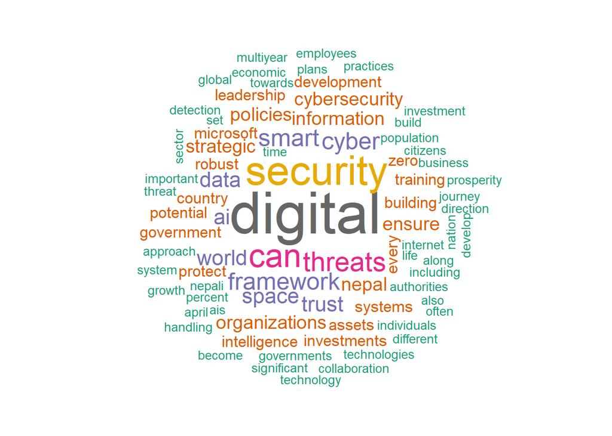

```r
set.seed(123)
wordcloud(words = names(freq), freq = freq, min.freq = 2, random.order = FALSE, colors = brewer.pal(8,"Dark2"))
```